# PUMP RA Interview Statistics

### Sample Dataset #1: Prospective Participants

#### Quantitative Data:

*Breakdown of undergraduate mentees:*

| Class Standing | Amount |
| --- | --- |
| 1-First-Year | 3 |
| 1-Freshman | 6 |
| 2-Sophomore | 13 |
| 3-Junior | 19 |
| 4-Senior | 9 |

*Breakdown of mentors:*

| Standing | Amount |
| --- | --- |
| Advanced undergraduate student | 10 |
| Faculty | 7 |
| Graduate student | 11 |
| Junior Undergraduate | 1 |
| Junior Undergraduate (rising senior) | 1 |
| Junior undergraduate student | 2 |
| Junior undergraduate student (graduating in 2022) | 1 |
| Postdoctoral Fellow | 1 |
| Research scientist or postdoc | 1 |
| Senior Research Scientist (dev) | 1 |
| Senior undergraduate student | 13 |

##### Gender Identity Percentages:

Male mentees: **8%**  
Female mentees: **90%**  
Non-binary mentees: **2%**

##### Ethnic/Race Percentages:

Amount of *African American* mentees: **12%**  
Amount of *East Asian* mentees: **32%**  
Amount of *Filipino* mentees: **4%**  
Amount of *Latinx* mentees: **18%**  
Amount of *Middle Eastern* mentees: **2%**  
Amount of *South Asian* mentees: **8%**  
Amount of *South East Asian* mentees: **2%**  
Amount of *White* mentees: **36%**

##### Additional Percentages of Underrepresented Identities:

Queer mentees: **6%**  
First-generation college students: **20%**

##### Visualization of Areas of Interest of Mentees:

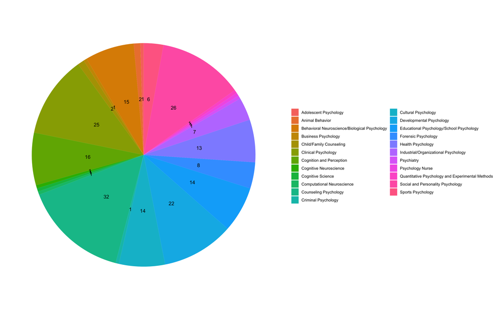

#### Qualitative Data:

Themes in the response *“What is your primary reason for seeking a psychology mentor?”*

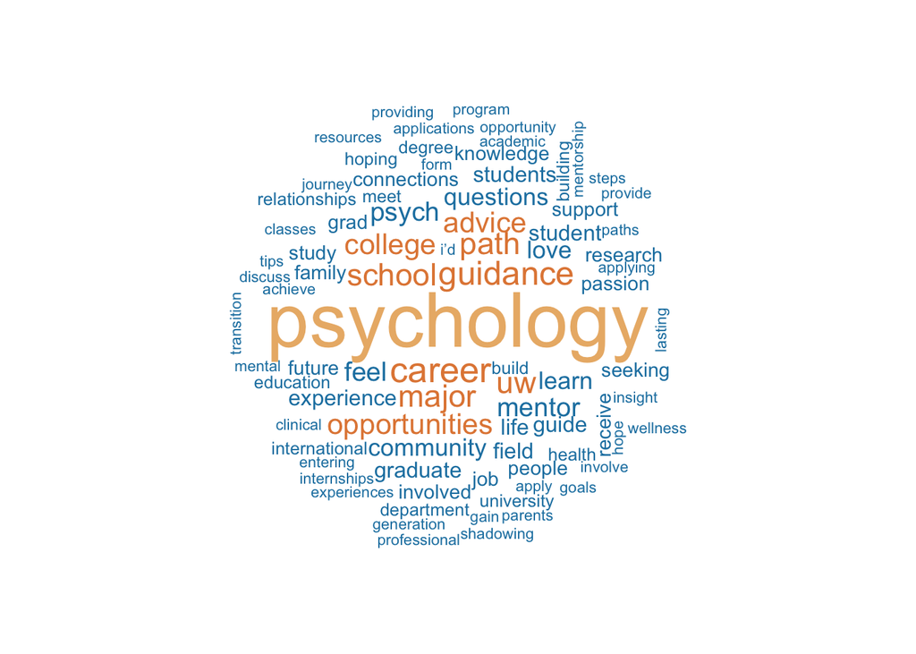

### Sample Dataset #2: Current Participant Survey

#### Quantitative Data:

Mentees who are interested in continuing with the same mentor: **One, Two, Six, Ten, Eleven, Fifteen, Sixteen, Seventeen, Eighteen, Nineteen, Twentyone**  
Mentees who are maybe interested in continuing with the same mentor: **Five, Seven, Eight, Thirteen**  
Mentees who need to be rematched with a new mentor: **One, Ten, Fourteen, Sixteen, Eighteen, Nineteen, Twentytwo**  
Mentees who maybe need to be rematched with a new mentor: **Four, Five, Eight, Eleven, Thirteen, Seventeen, Twenty, Twentyone**  
Mentees who want to become a mentor next year: **Six, Ten, Nineteen, Twentytwo**

*“How has your mentoring relationship impacted your feelings of belonging in the UW Department of Psychology?”*

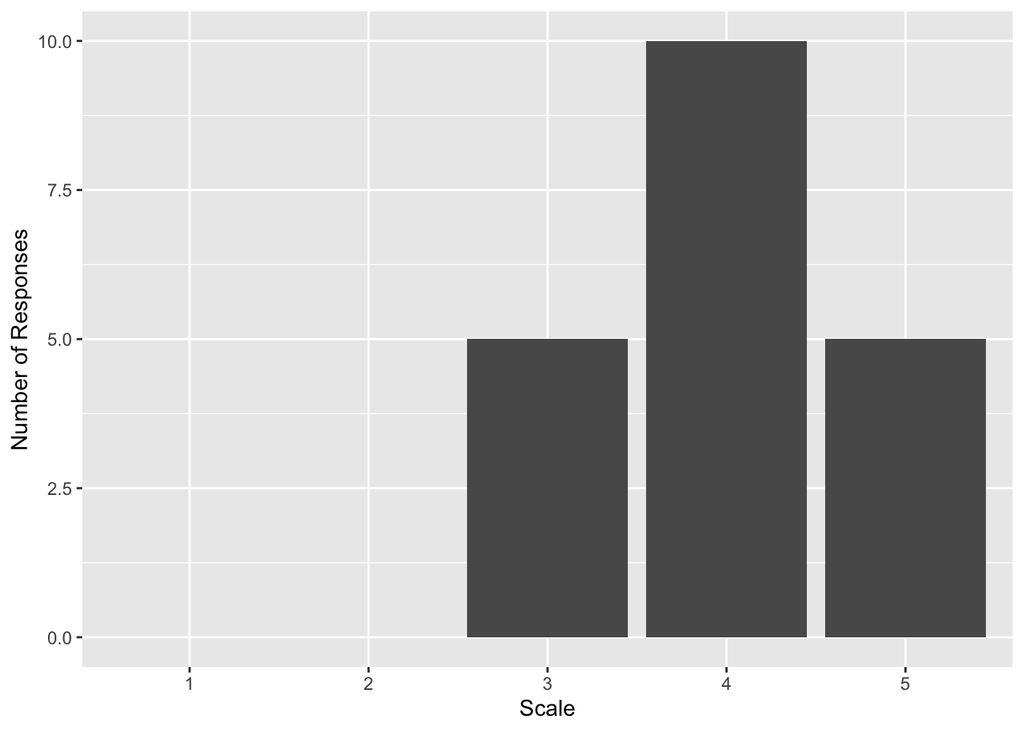

#### Qualitative Data:

Themes in responses to the following two questions:  
*“People can seek mentorship relationship for a variety of reasons… What’s your reason for participating in this program?”*

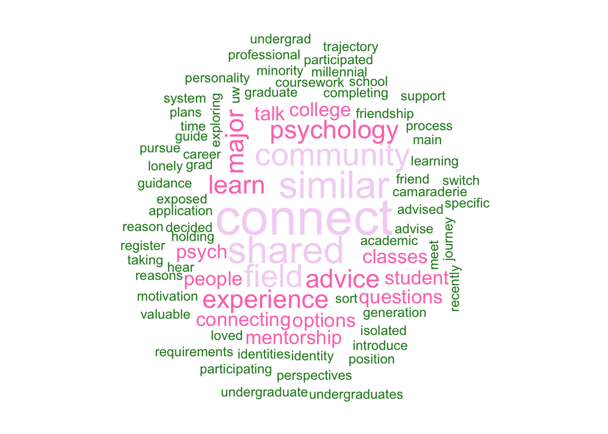

*“What have you learned from your mentor?”*

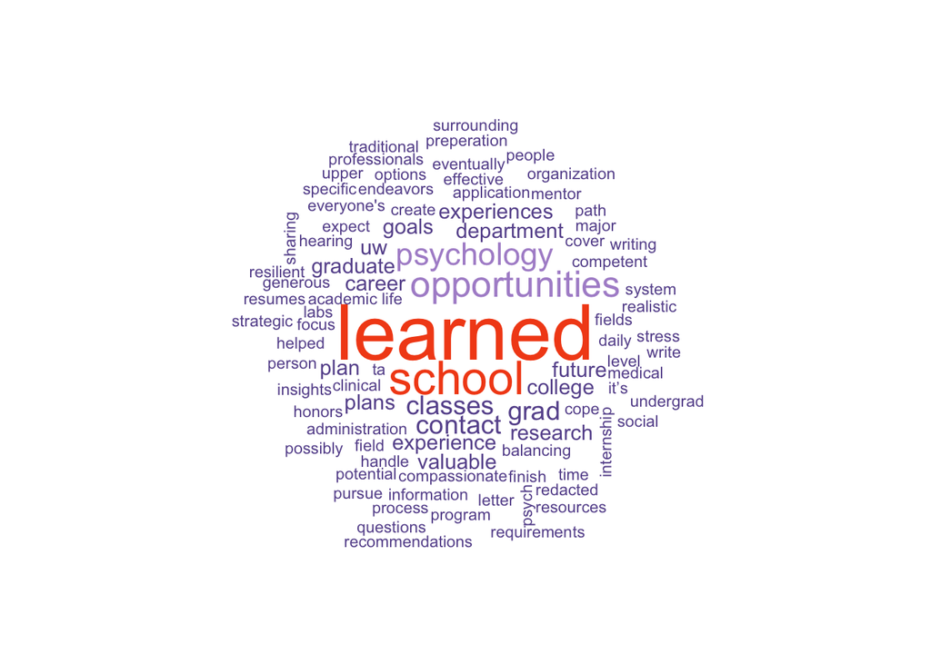